# Tufte Handout

An implementation in R Markdown

JJ Allaire and Yihui Xie

2017-10-17

# Introduction

The Tufte handout style is a style that Edward Tufte uses in his books and handouts. Tufte’s style is known for its extensive use of sidenotes, tight integration of graphics with text, and well-set typography. This style has been implemented in LaTeX and HTML/CSS, respectively. We have ported both implementations into the [**tufte** package](https://github.com/rstudio/tufte). If you want LaTeX/PDF output, you may use the `tufte_handout` format for handouts, and `tufte_book` for books. For HTML output, use `tufte_html`. These formats can be either specified in the YAML metadata at the beginning of an R Markdown document (see an example below), or passed to the `rmarkdown::render()` function. See Allaire et al. (2017) more information about **rmarkdown**.

See Github repositories tufte-latex and tufte-css

Allaire, JJ, Joe Cheng, Yihui Xie, Jonathan McPherson, Winston Chang, Jeff Allen, Hadley Wickham, Aron Atkins, Rob Hyndman, and Ruben Arslan. 2017. *Rmarkdown: Dynamic Documents for R*. https://CRAN.R-project.org/package=rmarkdown.

```yaml
---
title: "An Example Using the Tufte Style"
author: "John Smith"
output:
  tufte::tufte_handout: default
  tufte::tufte_html: default
---
```

There are two goals of this package:

1. To produce both PDF and HTML output with similar styles from the same R Markdown document;
2. To provide simple syntax to write elements of the Tufte style such as side notes and margin figures, e.g. when you want a margin figure, all you need to do is the chunk option `fig.margin = TRUE`, and we will take care of the deails for you, so you never need to think about `\begin{marginfigure} \end{marginfigure}` or `<span class="marginfigure"> </span>`; the LaTeX and HTML code under the hood may be complicated, but you never need to learn or write such code.

If you have any feature requests or find bugs in **tufte**, please do not hesitate to file them to https://github.com/rstudio/tufte/issues. For general questions, you may ask them on StackOverflow: http://stackoverflow.com/tags/rmarkdown.

# Headings

This style provides first and second-level headings (that is, `#` and `##`), demonstrated in the next section. You may get unexpected output if you try to use `###` and smaller headings.

In his later books, Tufte starts each section with a bit of vertical space, a non-indented paragraph, and sets the first few words of the sentence in small caps. To accomplish this using this style, call the `newthought()` function in **tufte** in an *inline R expression* `` `r ` `` as demonstrated at the beginning of this paragraph.

[Beautiful Evidence](http://www.edwardtufte.com/tufte/books_be)

Note you should not assume **tufte** has been attached to your R session. You should either `library(tufte)` in your R Markdown document before you call `newthought()`, or use `tufte::newthought()`.

# Figures

## Margin Figures

Images and graphics play an integral role in Tufte’s work. To place figures in the margin you can use the **knitr** chunk option `fig.margin = TRUE`. For example:

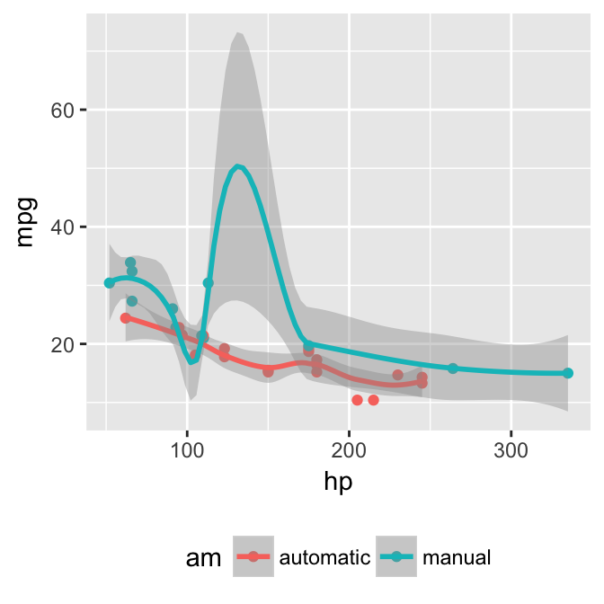

MPG vs horsepower, colored by transmission.

```r
library(ggplot2)
mtcars2 <- mtcars
mtcars2$am <- factor(
  mtcars$am, labels = c('automatic', 'manual')
)
ggplot(mtcars2, aes(hp, mpg, color = am)) +
  geom_point() + geom_smooth() +
  theme(legend.position = 'bottom')
```

Note the use of the `fig.cap` chunk option to provide a figure caption. You can adjust the proportions of figures using the `fig.width` and `fig.height` chunk options. These are specified in inches, and will be automatically scaled down to fit within the handout margin.

## Arbitrary Margin Content

In fact, you can include anything in the margin using the **knitr** engine named `marginfigure`. Unlike R code chunks `` ```{r} ``, you write a chunk starting with `` ```{marginfigure} `` instead, then put the content in the chunk. See an example on the right about the first fundamental theorem of calculus.

We know from *the first fundamental theorem of calculus* that for *x* in [*a*, *b*]:
$$\frac{d}{dx}\left( \int_{a}^{x} f(u)\,du\right)=f(x).$$

For the sake of portability between LaTeX and HTML, you should keep the margin content as simple as possible (syntax-wise) in the `marginefigure` blocks. You may use simple Markdown syntax like `**bold**` and `_italic_` text, but please refrain from using footnotes, citations, or block-level elements (e.g. blockquotes and lists) there.

## Full Width Figures

You can arrange for figures to span across the entire page by using the chunk option `fig.fullwidth = TRUE`.

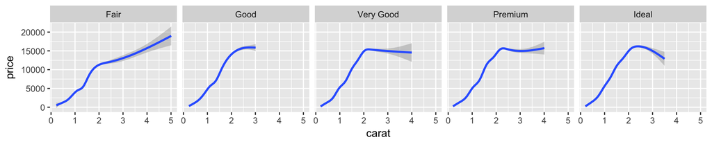

A full width figure.

```r
ggplot(diamonds, aes(carat, price)) + geom_smooth() +
  facet_grid(~ cut)
```

Other chunk options related to figures can still be used, such as `fig.width`, `fig.cap`, `out.width`, and so on. For full width figures, usually `fig.width` is large and `fig.height` is small. In the above example, the plot size is $10 \times 2$.

## Main Column Figures

Besides margin and full width figures, you can of course also include figures constrained to the main column. This is the default type of figures in the LaTeX/HTML output.

A figure in the main column.

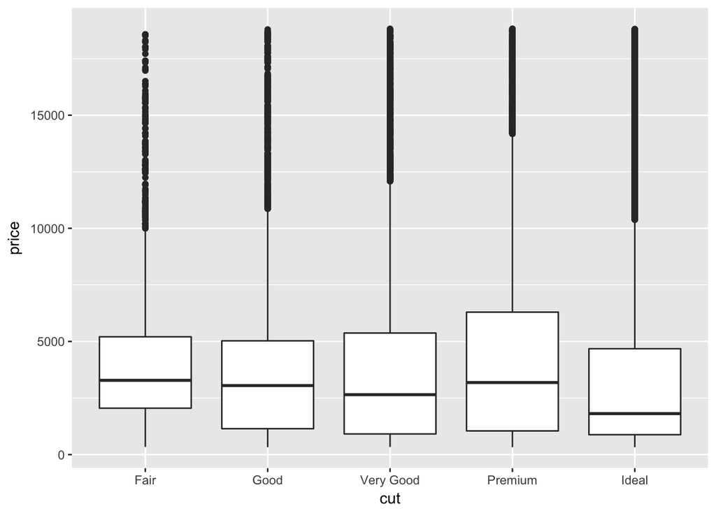

```r
ggplot(diamonds, aes(cut, price)) + geom_boxplot()
```

# Sidenotes

One of the most prominent and distinctive features of this style is the extensive use of sidenotes. There is a wide margin to provide ample room for sidenotes and small figures. Any use of a footnote will automatically be converted to a sidenote.

This is a sidenote that was entered using a footnote.

If you’d like to place ancillary information in the margin without the sidenote mark (the superscript number), you can use the `margin_note()` function from **tufte** in an inline R expression. This function does not process the text with Pandoc, so Markdown syntax will not work here. If you need to write anything in Markdown syntax, please use the `marginfigure` block described previously.

This is a margin note. Notice that there is no number preceding the note.

# References

References can be displayed as margin notes for HTML output. For example, we can cite R here (R Core Team 2017). To enable this feature, you must set `link-citations: yes` in the YAML metadata, and the version of `pandoc-citeproc` should be at least 0.7.2. You can always install your own version of Pandoc from http://pandoc.org/installing.html if the version is not sufficient. To check the version of `pandoc-citeproc` in your system, you may run this in R:

R Core Team. 2017. *R: A Language and Environment for Statistical Computing*. Vienna, Austria: R Foundation for Statistical Computing. https://www.R-project.org/.

```r
system2('pandoc-citeproc', '--version')
```

If your version of `pandoc-citeproc` is too low, or you did not set `link-citations: yes` in YAML, references in the HTML output will be placed at the end of the output document.

# Tables

You can use the `kable()` function from the **knitr** package to format tables that integrate well with the rest of the Tufte handout style. The table captions are placed in the margin like figures in the HTML output.

```r
knitr::kable(
  mtcars[1:6, 1:6], caption = 'A subset of mtcars.'
)
```

A subset of mtcars.

|  | mpg | cyl | disp | hp | drat | wt |
| --- | --- | --- | --- | --- | --- | --- |
| Mazda RX4 | 21.0 | 6 | 160 | 110 | 3.90 | 2.620 |
| Mazda RX4 Wag | 21.0 | 6 | 160 | 110 | 3.90 | 2.875 |
| Datsun 710 | 22.8 | 4 | 108 | 93 | 3.85 | 2.320 |
| Hornet 4 Drive | 21.4 | 6 | 258 | 110 | 3.08 | 3.215 |
| Hornet Sportabout | 18.7 | 8 | 360 | 175 | 3.15 | 3.440 |
| Valiant | 18.1 | 6 | 225 | 105 | 2.76 | 3.460 |

# Block Quotes

We know from the Markdown syntax that paragraphs that start with `>` are converted to block quotes. If you want to add a right-aligned footer for the quote, you may use the function `quote_footer()` from **tufte** in an inline R expression. Here is an example:

> “If it weren’t for my lawyer, I’d still be in prison. It went a lot faster with two people digging.”

Without using `quote_footer()`, it looks like this (the second line is just a normal paragraph):

> “Great people talk about ideas, average people talk about things, and small people talk about wine.”

> — Fran Lebowitz

# Responsiveness

The HTML page is responsive in the sense that when the page width is smaller than 760px, sidenotes and margin notes will be hidden by default. For sidenotes, you can click their numbers (the superscripts) to toggle their visibility. For margin notes, you may click the circled plus signs to toggle visibility.

# More Examples

The rest of this document consists of a few test cases to make sure everything still works well in slightly more complicated scenarios. First we generate two plots in one figure environment with the chunk option `fig.show = 'hold'`:

Two plots in one figure environment.

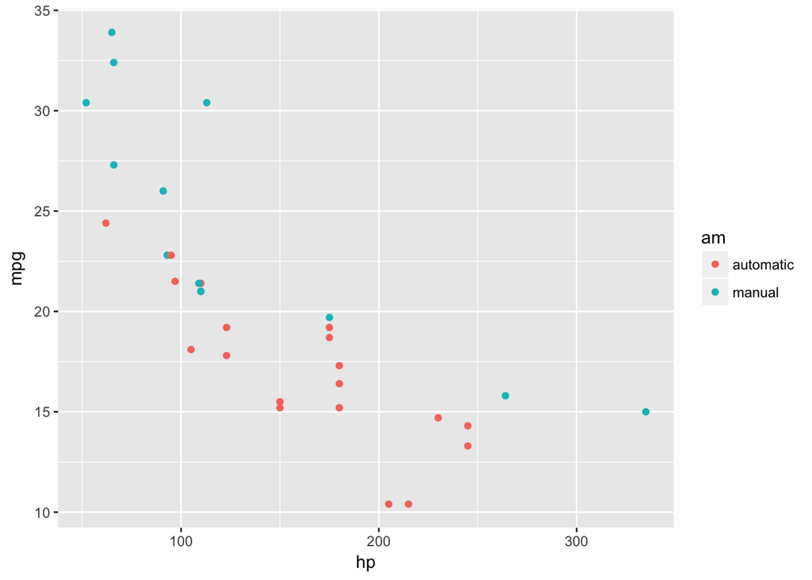

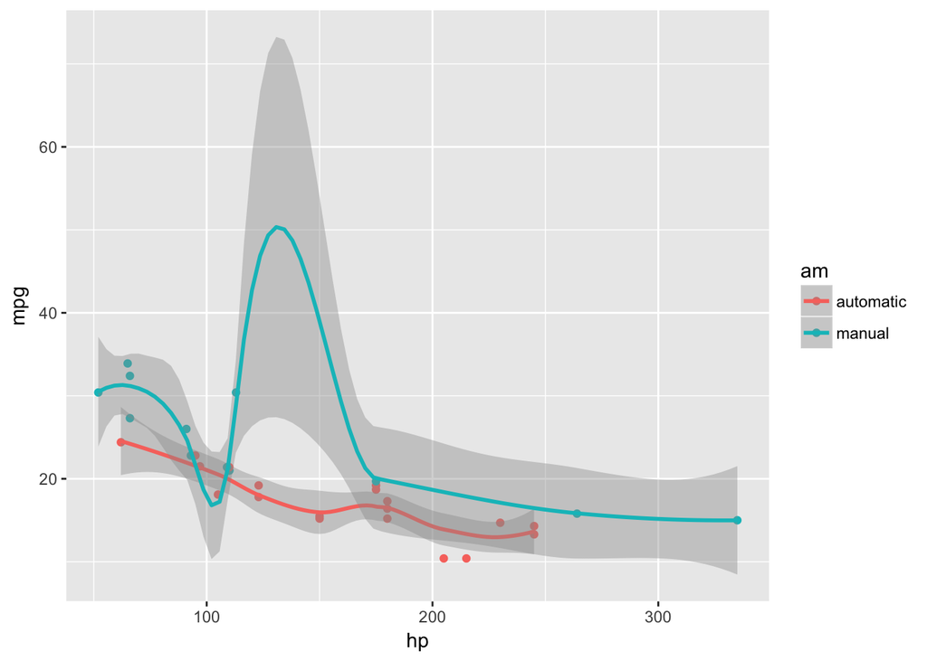

```r
p <- ggplot(mtcars2, aes(hp, mpg, color = am)) +
  geom_point()
p
p + geom_smooth()
```

Then two plots in separate figure environments (the code is identical to the previous code chunk, but the chunk option is the default `fig.show = 'asis'` now):

Two plots in separate figure environments (the first plot).

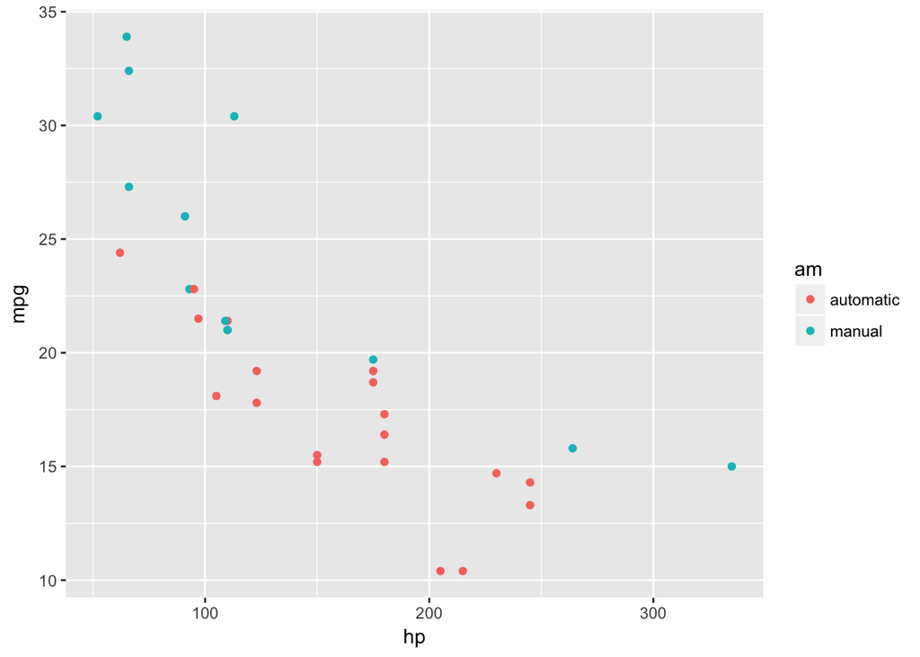

```r
p <- ggplot(mtcars2, aes(hp, mpg, color = am)) +
  geom_point()
p
```

Two plots in separate figure environments (the second plot).

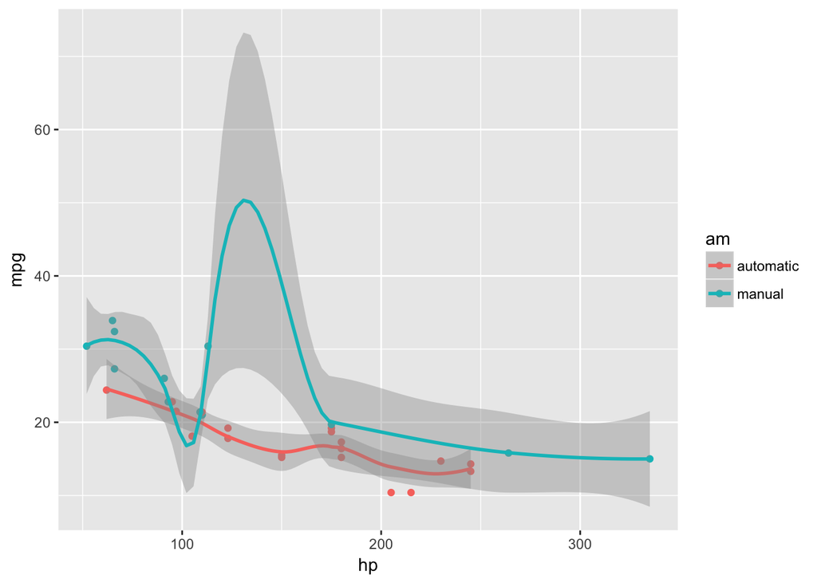

```r
p + geom_smooth()
```

You may have noticed that the two figures have different captions, and that is because we used a character vector of length 2 for the chunk option `fig.cap` (something like `fig.cap = c('first plot', 'second plot')`).

Next we show multiple plots in margin figures. Similarly, two plots in the same figure environment in the margin:

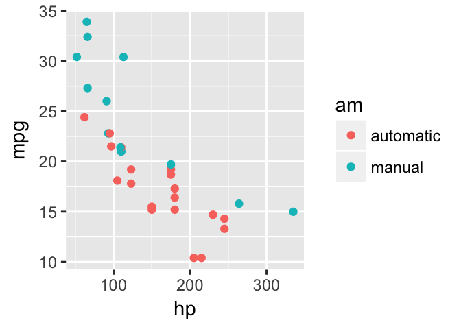

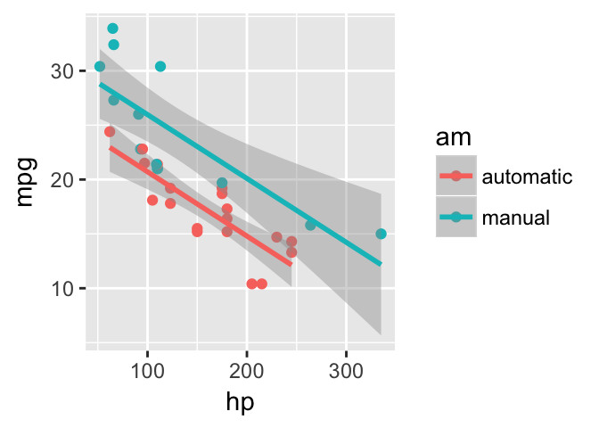

Two plots in one figure environment in the margin.

```r
p
p + geom_smooth(method = 'lm')
```

Then two plots from the same code chunk placed in different figure environments:

```r
knitr::kable(head(iris, 15))
```

| Sepal.Length | Sepal.Width | Petal.Length | Petal.Width | Species |
| --- | --- | --- | --- | --- |
| 5.1 | 3.5 | 1.4 | 0.2 | setosa |
| 4.9 | 3.0 | 1.4 | 0.2 | setosa |
| 4.7 | 3.2 | 1.3 | 0.2 | setosa |
| 4.6 | 3.1 | 1.5 | 0.2 | setosa |
| 5.0 | 3.6 | 1.4 | 0.2 | setosa |
| 5.4 | 3.9 | 1.7 | 0.4 | setosa |
| 4.6 | 3.4 | 1.4 | 0.3 | setosa |
| 5.0 | 3.4 | 1.5 | 0.2 | setosa |
| 4.4 | 2.9 | 1.4 | 0.2 | setosa |
| 4.9 | 3.1 | 1.5 | 0.1 | setosa |
| 5.4 | 3.7 | 1.5 | 0.2 | setosa |
| 4.8 | 3.4 | 1.6 | 0.2 | setosa |
| 4.8 | 3.0 | 1.4 | 0.1 | setosa |
| 4.3 | 3.0 | 1.1 | 0.1 | setosa |
| 5.8 | 4.0 | 1.2 | 0.2 | setosa |

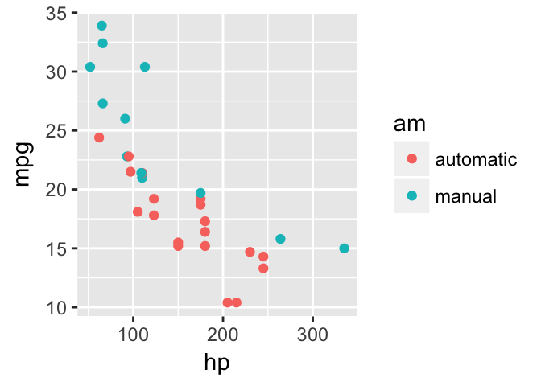

Two plots in separate figure environments in the margin (the first plot).

```r
p
```

```r
knitr::kable(head(iris, 12))
```

| Sepal.Length | Sepal.Width | Petal.Length | Petal.Width | Species |
| --- | --- | --- | --- | --- |
| 5.1 | 3.5 | 1.4 | 0.2 | setosa |
| 4.9 | 3.0 | 1.4 | 0.2 | setosa |
| 4.7 | 3.2 | 1.3 | 0.2 | setosa |
| 4.6 | 3.1 | 1.5 | 0.2 | setosa |
| 5.0 | 3.6 | 1.4 | 0.2 | setosa |
| 5.4 | 3.9 | 1.7 | 0.4 | setosa |
| 4.6 | 3.4 | 1.4 | 0.3 | setosa |
| 5.0 | 3.4 | 1.5 | 0.2 | setosa |
| 4.4 | 2.9 | 1.4 | 0.2 | setosa |
| 4.9 | 3.1 | 1.5 | 0.1 | setosa |
| 5.4 | 3.7 | 1.5 | 0.2 | setosa |
| 4.8 | 3.4 | 1.6 | 0.2 | setosa |

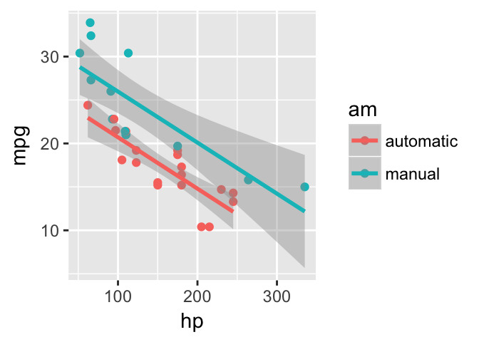

Two plots in separate figure environments in the margin (the second plot).

```r
p + geom_smooth(method = 'lm')
```

```r
knitr::kable(head(iris, 5))
```

| Sepal.Length | Sepal.Width | Petal.Length | Petal.Width | Species |
| --- | --- | --- | --- | --- |
| 5.1 | 3.5 | 1.4 | 0.2 | setosa |
| 4.9 | 3.0 | 1.4 | 0.2 | setosa |
| 4.7 | 3.2 | 1.3 | 0.2 | setosa |
| 4.6 | 3.1 | 1.5 | 0.2 | setosa |
| 5.0 | 3.6 | 1.4 | 0.2 | setosa |

We blended some tables in the above code chunk only as *placeholders* to make sure there is enough vertical space among the margin figures, otherwise they will be stacked tightly together. For a practical document, you should not insert too many margin figures consecutively and make the margin crowded.

You do not have to assign captions to figures. We show three figures with no captions below in the margin, in the main column, and in full width, respectively.

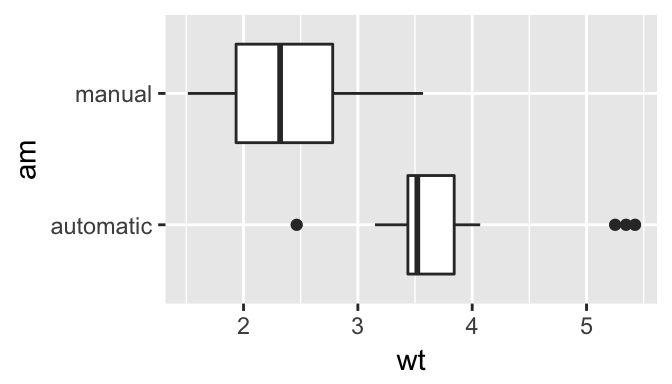

```r
# a boxplot of weight vs transmission; this figure
# will be placed in the margin
ggplot(mtcars2, aes(am, wt)) + geom_boxplot() +
  coord_flip()
```

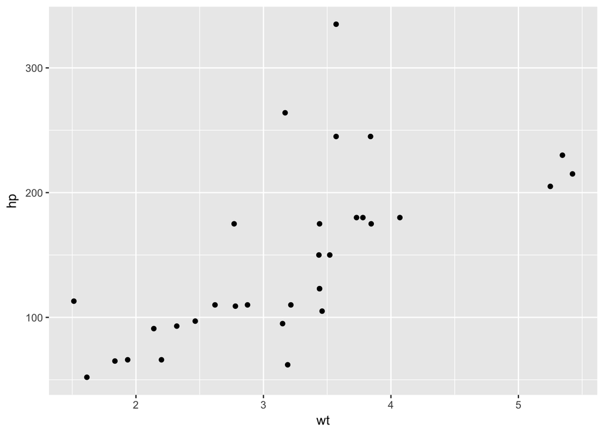

```r
# a figure in the main column
p <- ggplot(mtcars, aes(wt, hp)) + geom_point()
p
```

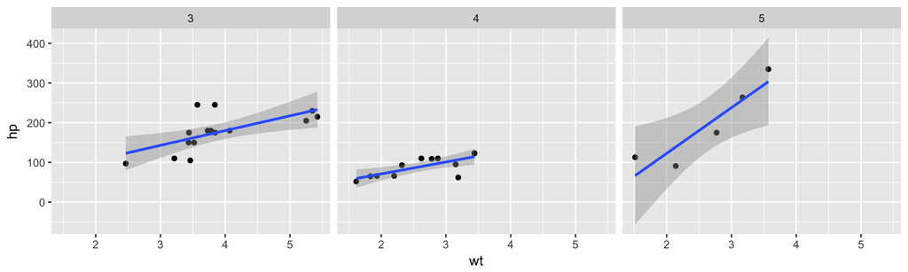

```r
# a fullwidth figure
p + geom_smooth(method = 'lm') + facet_grid(~ gear)
```

# Some Notes on Tufte CSS

There are a few other things in Tufte CSS that we have not mentioned so far. If you prefer sans-serif fonts, use the function `sans_serif()` in **tufte**. For epigraphs, you may use a pair of underscores to make the paragraph italic in a block quote, e.g.

> *I can win an argument on any topic, against any opponent. People know this, and steer clear of me at parties. Often, as a sign of their great respect, they don’t even invite me.*

We hope you will enjoy the simplicity of R Markdown and this R package, and we sincerely thank the authors of the Tufte-CSS and Tufte-LaTeX projects for developing the beautiful CSS and LaTeX classes. Our **tufte** package would not have been possible without their heavy lifting.

To see the R Markdown source of this example document, you may follow [this link to Github](https://github.com/rstudio/tufte/raw/master/inst/rmarkdown/templates/tufte_html/skeleton/skeleton.Rmd), use the wizard in RStudio IDE (`File -> New File -> R Markdown -> From Template`), or open the Rmd file in the package:

```r
file.edit(
  tufte:::template_resources(
    'tufte_html', '..', 'skeleton', 'skeleton.Rmd'
  )
)
```

## Summary of pollock results

# Data

New data presented in this assessment suggests that the above average 2008 year-class is slightly higher than before and that the 2012 year-class also appears to be above average. As such, the maximum permissible Tier 1a ABC remains high. Tier 3 estimates of ABC are also quite high; however, besides adding stability in catch rates and effort, an ABC based on the Tier 3 values is recommended (2,800,000 t) which is well below the maximum permissible (Tier 1a) value of 3,120,000 t. The Tier 1a overfishing level (OFL) is estimated to be 3,640,000 t.

## Response to SSC and Plan Team comments

### General comments

From the December 2015 SSC minutes: The SSC reminds the authors and PTs to follow the model-numbering scheme adopted at the December 2014 meeting.

We followed the model-numbering scheme described in the most recent version of the SAFE Guidelines (Option D). The SSC encourages the authors and PTs to refer to the forthcoming CAPAM data-weighting workshop report. Sample sizes for the fishery data were re-evaluated to obtain alternative time-varying inputs—these were rescaled according to estimated “Francis weights” (method TA1.8; Francis 2011) from model fits and evaluated against alternative levels of flexibility in time and age-varying selectivity.

The SSC recommends that assessment authors work with AFSC’s survey program scientist to develop some objective criteria to inform the best approaches for calculating Q with respect to information provided by previous survey trawl performance studies (e.g. Somerton and Munro 2001), and fish-temperature relationships which may impact Q. The survey catchability was freely estimated in this model and values are examined for general consistency with biological aspects of pollock (which are known to vary in proximity to the bottom with age and between years).

### Comments specific to this assessment

In the September 2016 minutes, the BSAI Plan Team recommended: “… that the authors develop a better prior for steepness, or at least a better rationale, and perhaps consider a meta-analytic approach. The Team recommends using biomass in the AT and BTS (his Model 4 in the presentation), which also includes the bottom 2.5 m of the acoustic biomass. In the long term, the Team recommends evaluating the sample sizes used for the data weighting and pursuing other CIE suggestions.

The AT and BTS data are treated as biomass indices in this assessment. Sample size estimates were re-evaluated and used in the recommended model below. An alternative degree of uncertainty, which notes differences from the CEATTLE stock-recruit relationship was provided as an alternative (but is unfortunately lacking in meta-analytic rigor). The age compositions for including the bottom 2.5 meters from the acoustic data were unavailable in time for this assessment and will be applied in the coming year.

# Introduction

Walleye pollock (Gadus chalcogrammus; hereafter referred to as pollock) are broadly distributed throughout the North Pacific with the largest concentrations found in the Eastern Bering Sea. Also marketed under the name Alaska pollock, this species continues to represent over 40% of the global whitefish production, with the market disposition split fairly evenly between fillets, whole fish (headed and gutted), and surimi (Fissel et al. 2014). An important component of the commercial production is the sale of roe from pre-spawning pollock. Pollock are considered a relatively fast growing and short-lived species. They play an important role in the Bering Sea ecosystem.

## Stock structure

A summary of EBS pollock stock structure was presented at the September 2015 BSAI Plan Team meetings. From that review the Team and SSC concurred that the current stock structure hypothesis for management purposes was of little or no concern.

# Fishery

EBS pollock catches were low until directed foreign fisheries began in 1964. Catches increased rapidly during the late 1960s and reached a peak in 1970-75 when they ranged from 1.3 to 1.9 million t annually (Fig. 1.1). Following the peak catch in 1972, bilateral agreements with Japan and the USSR resulted in reductions. Since 1977 (when the U.S. EEZ was declared) the annual average EBS pollock catch has been about 1.2 million t, ranging from 0.815 million t in 2009 to nearly 1.5 million t during 2003-2006 (Fig. 1.1). United States vessels began fishing for pollock in 1980 and by 1987 they were able to take 99% of the quota. Since 1988, only U.S. vessels have been operating in this fishery. Observers collected data aboard the foreign vessels since the late 1970s. The current observer program for the domestic fishery formally began in 1991 and has since then regularly re-evaluated the sampling protocol and making adjustments where needed to improve efficiency. Since 2011, regulations require that all vessels participating in the pollock fishery carry at least one observer. Prior to this time about 70-80% of the catch was observed at sea or during dockside offloading. During a 10-year period, catches by foreign vessels operating in the “Donut Hole” region of the Aleutian Basin were substantial totaling nearly 7 million t (Table 1.1). A fishing moratorium was enacted in 1993 and only trace amounts of pollock have been harvested from the Aleutian Basin region since then.

## Management measures

The EBS pollock stock is managed by NMFS regulations that provide limits on seasonal catch. The NMFS observer program data provide near real-time statistics during the season and vessels operate within well-defined limits. TACs have commonly been set well below the ABC value and catches have usually stayed within these constraints (Table 1.2). Allocations of the TAC split first with 10% to western Alaska communities as part of the Community Development Quota (CDQ) program and the remainder between at-sea processors and shore-based sectors. In recent studies, Haynie (2014) characterized the CDQ program and Seung and Ianelli (2016) combine a fish population dynamics model with an economic model to evaluate regional impacts.

Due to concerns over possible impacts groundfish fisheries may have on rebuilding populations of Steller sea lions, a number of management measures have been implemented. Some measures were designed to reduce the possibility of competitive interactions between fisheries and Steller sea lions. For the pollock fisheries, seasonal fishery catch and pollock biomass distributions (from surveys) indicated that the apparent disproportionately high seasonal harvest rates within Steller sea lion critical habitat could lead to reduced sea lion prey densities. Consequently, management measures redistributed the fishery both temporally and spatially according to pollock biomass distributions. This was intended to disperse fishing so that localized harvest rates were more consistent with annual exploitation rates. The measures include establishing: 1) pollock fishery exclusion zones around sea lion rookery or haulout sites; 2) phased-in reductions in the seasonal proportions of TAC that can be taken from critical habitat; and 3) additional seasonal TAC releases to disperse the fishery in time.

Prior to adoption of the above management measures, the pollock fishery occurred in each of the three major NMFS management regions of the North Pacific Ocean: the Aleutian Islands (1,001,780 km2 inside the EEZ), the Eastern Bering Sea (968,600 km2), and the Gulf of Alaska (1,156,100 km2). The marine portion of Steller sea lion critical habitat in Alaska west of 150°W encompasses 386,770 km2 of ocean surface, or 12% of the fishery management regions.

Prior to 1999, 84,100 km2, or 22% of critical habitat was closed to the pollock fishery. Most of this closure consisted of the 10- and 20-nm radius all-trawl fishery exclusion zones around sea lion rookeries (48,920 km2, or 13% of critical habitat). The remainder was largely management area 518 (35,180 km2, or 9% of critical habitat) that was closed pursuant to an international agreement to protect spawning stocks of central Bering Sea pollock.

In 1999, an additional 83,080 km2 (21%) of critical habitat in the Aleutian Islands was closed to pollock fishing along with 43,170 km2 (11%) around sea lion haulouts in the GOA and Eastern Bering Sea. In 1998, over 22,000 t of pollock were caught in the Aleutian Island region, with over 17,000 t taken within critical habitat region. Between 1999 and 2004 a directed fishery for pollock was prohibited in this region. Subsequently, 210,350 km2 (54%) of critical habitat was closed to the pollock fishery. In 2000 the remaining phased-in reductions in the proportions of seasonal TAC that could be caught within the BSAI Steller sea lion Conservation Area (SCA) were implemented.

On the EBS shelf, an estimate (based on observer at-sea data) of the proportion of pollock caught in the SCA has averaged about 38% annually. During the A-season, the average is about 42% (in part because pre-spawning pollock are more concentrated in this area during this period). The proportion of pollock caught within the SCA varies considerably, presumably due to temperature regimes and population age structure. The annual proportion of catch within the SCA varies and has ranged from an annual low of 11% in 2010 to high of 51% in 2016 (Table 1.3). This high value was due to B-season conditions which had 62% of the catch taken in this region.

The 1998 American Fisheries Act (AFA) reduced the capacity of the catcher/processor fleet and permitted the formation of cooperatives in each industry sector by the year 2000. Because of some of its provisions, the AFA gave the industry the ability to respond efficiently to changes mandated for sea lion conservation and salmon bycatch measures. Without such a catch-share program, these additional measures would likely have been less effective and less economical (Strong and Criddle 2014).

An additional strategy to minimize potential adverse effects on sea lion populations is to disperse the fishery throughout more of the pollock range on the Eastern Bering Sea shelf. While the distribution of fishing during the A-season is limited due to ice and weather conditions, there appears to be some dispersion to the northwest area (Fig. 1.3).

The majority (~56%) of Chinook salmon caught as bycatch in the pollock fishery originate from western Alaskan rivers. An Environmental Impact Statement (EIS) was completed in 2009 in conjunction with the Council’s recommended management approach. This EIS evaluated the relative impacts of different bycatch management approaches as well as estimated the impact of bycatch levels on adult equivalent salmon (AEQ) returning to river systems (NMFS/NPFMC 2009). As a result, revised salmon bycatch management measures went into effect in 2011imposing prohibited species catch (PSC) limits that when reached would close the fishery by sector and season (Amendment 91 to the Groundfish FMP resulting from the NPFMC’s 2009 action). Previously, all measures for salmon bycatch imposed seasonal area closures when PSC levels reached the limit (fishing could continue outside of the closed areas). The new program imposes a dual cap system broken out by fishing sector and season. The management measure was designed to keep the annual bycatch below the lower cap by providing incentives to avoid bycatch. Additionally, in order to participate, vessels must take part in an incentive program agreement (IPA). These IPAs are approved by NMFS and are designed for further bycatch reduction and individual vessel accountability. The fishery has been operating under rules to implement this program since January 2011. During 2008 - 2016, bycatch levels for Chinook salmon have been well below average following record high levels in 2007. This is likely due to industry-based restrictions on areas where pollock fishing may occur, environmental conditions, Amendment 91 measures, and salmon abundance.

Further measures to reduce salmon bycatch in the pollock fishery were developed and the Council took action on Amendment 110 to the BSAI Groundfish FMP in April 2015. These additional measures were designed to add protection for Chinook salmon by imposing more restrictive PSC limits in times of low western Alaskan Chinook salmon abundance. This included provisions within the IPAs that reduce fishing in months of higher bycatch encounters and mandate the use of salmon excluders in trawl nets. These provisions were also included to manage chum salmon bycatch within the IPAs rather than through Amendment 84 to the FMP. The new measure also included additional seasonal flexibility in pollock fishing so that more pollock (proportionally) could be caught during seasons when salmon bycatch rates were low. Specifically, an additional 5% of the pollock can be caught in the Aseason (effectively changing the seasonal allocation from 40% to 45%). These measures are all part of Amendment 110 and a summary of this and other key management measures is provided in Table 1.4.

# Fishery characteristics

## General catch patterns

The “A-season” for directed EBS pollock fishing opens on January 20th and extends into early-mid April. During this season, the fishery produces highly valued roe that, under optimal conditions, can comprise over 4% of the catch in weight. The second, or “B-season” presently opens on June 10th and extends through noon on November 1st. The A-season fishery concentrates primarily north and west of Unimak Island depending on ice conditions and fish distribution. There has also been effort along the 100 m contour (and deeper) between Unimak Island and the Pribilof Islands. Since 2011, regulations and industry-based measures to reduce salmon bycatch have affected the spatial distribution of the fishery and to some degree, the way individual vessel operators fish (Stram and Ianelli, 2014). The catch estimates by sex for the A-season compared to estimates for the entire season indicate that over time, the number of males and females has been fairly equal (Fig. 1.2). The 2016 and 2014 A-season fishery spatial pattern had relatively high concentrations of fishing on the shelf north of Unimak Island, especially compared to the pattern observed in 2015 when most fishing activity occurred farther north (Fig. 1.3).

Pollock retained and discarded catch (based on NMFS observer estimates) in the Eastern Bering Sea and Aleutian Islands for 1991-2016 are shown in Table 1.5. Since 1991, estimates of discarded pollock have ranged from a high of 9.1% of total pollock catch in 1992 to recent lows of around 0.6%. These low values reflect the implementation of the Council’s Improved Retention /Improved Utilization program. Prior to the implementation of the AFA in 1999, higher discards may have occurred under the “race for fish” and incidental catch of pollock that were below marketable sizes. Since implementation of the AFA, the vessel operators have more time to pursue optimal sizes of pollock for market since the quota is allocated to vessels (via cooperative arrangements). In addition, several vessels have made gear modifications to avoid retention of smaller pollock. In all cases, the magnitude of discards counts as part of the total catch for management (to ensure the TAC is not exceeded) and within the assessment. Bycatch of other non-target, target, and prohibited species is presented in the section titled Ecosystem Considerations below. In that section it is noted that the bycatch of pollock in other target fisheries is more than double the bycatch of other target species (e.g., Pacific cod) in the pollock fishery.

## Economic conditions as of 2015

Alaska pollock is the dominant species in terms of catch in the Bering Sea and Aleutian Island (BSAI) region. It accounted for 69% of the BSAI’s FMP groundfish harvest and 89% of the total pollock harvest in Alaska. Retained catch of pollock increased 2.2% to 1.3 million t in 2015. BSAI pollock first- wholesale value was $1.28 billion 2015, which was down slightly from $1.3 billion in 2014 but above the 2005-2007 average of $1.25 billion. The higher revenue in recent years is largely the result of increased catch and production levels as the average first-wholesale price of pollock products have declined since peaking in 2008-2010 and since 2013 have been below the 2005-2007 average, though this varies across products types.

Pollock is targeted exclusively with pelagic trawl gear. The catch of pollock in the BSAI was rationalized with the passage of the American Fisheries Act (AFA) in 1998, which, among other things, established a proportional allocation of the total allowable catch (TAC) among vessels in sectors which could form into cooperatives. Alaska-caught pollock in the BSAI became certified by the Marine Stewardship Council (MSC) in 2005, a NGO based third-party sustainability certification, which some buyers seek. In 2015 the official U.S. market name changed from “Alaska pollock” to “pollock” enabling U.S. retailers to differentiate between pollock caught in Alaska and Russia.

Prior to 2008 pollock catches were high at approximately 1.4 million t in the BSAI for an extended period (Tables 1.6). The U.S. accounted for over 50% of the global pollock catch (Table 1.7). Between 2008-2010 conservation reductions in the pollock total allowable catch (TAC) trimmed catches to an average 867 thousand t. The supply reduction resulted in price increases for most pollock products, which mitigated the short-term revenue loss (Table 1.8). Over this same period, the pollock catch in Russia increased from an average of 1 million t in 2005-2007 to 1.4 million t in 2008-2010 and Russia’s share of global catch increased to over 50% and the U.S. share decreased to 35%. Russia lacks the primary processing capacity of the U.S. and much of their catch is exported to China and is re-processed as twice-frozen fillets. Around the mid- to late-2000s, buyers in Europe, an important segment of the fillet market, started to source fish products with the MSC sustainability certification, and some major retailer in the U.S. later began to follow suit. Asian markets, an important export destination for several pollock products, have shown less interest in requiring MSC certification. The U.S. was the only producer of MSC certified pollock until 2013 when roughly 50% of the Russian catch became MSC certified. Since 2010 the U.S. pollock stock rebounded with catches in the BSAI ranging from 1.2-1.3 million t and Russia’s catch has stabilized at 1.5 to 1.6 million t. Most pollock are exported; consequently, exchange rates can have a significant impact on market dynamics, particularly the Dollar-Yen and Dollar-Euro. Additionally, pollock more broadly competes with other whitefish that, to varying degrees, can serve as substitutes depending on the product.

This market environment accounts for some of the major trends in prices and production across product types. Fillet prices peaked in 2008-2010 but declined afterwards because of the greater supply from U.S. and Russia. The 2013 MSC certification of Russian-caught pollock enabled access to segments of European and U.S. fillet markets, which has put continued downward pressure on prices. Pollock roe prices and production have declined steadily over the last decade as international demand has waned with changing consumer preferences in Asia. Additionally, the supply of pollock roe from Russia has increased with catch. The net effect has been not only a reduction in the supply of roe from the U.S. industry, but also a significant reduction in roe prices which are roughly half pre-2008 levels. Prior to 2008, roe comprised 23% of the U.S. wholesale value share, and since 2011 it has been roughly 10%. Within the U.S. the supply reduction in 2008-2010 surimi production from pollock came under increased pressure as U.S. pollock prices rose and markets sought cheaper sources of raw materials. This contributed to a growth in surimi from warm-water fish of southeast Asia. Surimi prices spiked in 2008-2010 and have since tapered off as production from warm-water species increased (as has pollock). A relatively small fraction of pollock caught in Russian waters is processed as surimi. Surimi is consumed globally, but Asian markets dominate the demand for surimi and demand has remained strong.

The catch of pollock can be broadly divided between the shore-based sector where catcher vessels make deliveries to inshore processors, and the at-sea sector where catch is processed at-sea by catcher/processors and motherships before going directly to the wholesale markets. The retained catch of the shore-based sector increased 3% increase to 687 thousand t. The value of these deliveries (shore-based ex-vessel value) totaled $227.3 million in 2015, which was roughly equal to the shore-based ex-vessel value in 2014, as the increased catch was offset by similar decrease in the ex-vessel price. The first-wholesale value of pollock products was $768 million for the at-sea sector and $516 million for the shore-based sector. The higher revenue in recent years is largely the result of increased catch levels as the average price of pollock products have declined since peaking in 2008-2010 and since 2013 have been below the 2005-2007 average, though this varies across products types. The average price of pollock products in 2015 increased slightly for the at-sea sector and decreased slightly for the shore-based sector, which was attributable to sectoral differences in price change of fillet and surimi products.

The portfolios of products shore-based and at-sea processors produce are similar. In both sectors the primary products processed from pollock are fillets, surimi and roe, with each accounting for approximately 40%, 35%, and 10% of first-wholesale value. The price of products produced at-sea tend to be higher than comparable products produced shore-based because of the shorter time span between catch, processing and freezing. The price of fillets produced at-sea tend to be about 10% higher, surimi prices tend to be about 20% higher and the price of roe about 40% higher. Average prices for fillets produced at-sea also tend to be higher because they produce proportionally more higher-priced fillet types (like deep-skin fillets). The at-sea price first wholesale premium averaged roughly $0.30 per pound between 2005-2010 but has decreased to an average of $0.19 per pound since 2011, in part, because the shore-based sector increased their relative share of surimi production.

A variety of different fillets are produced from pollock, with pin-bone-out (PBO) and deep-skin fillets accounting for approximately 70% and 30% of production in the BSAI, respectively. Total fillet production decreased 5% to 167 thousand t in 2015, but since 2010 has increased with aggregate production and catch and has been higher than the 2005-2007 average. The average price of fillet products in the BSAI decreased 1% to $1.35 per pound and is below the inflation adjusted average price of fillets in 2005-2007 of $1.44 per pound. Price negotiations with European buyers in 2015 were difficult with buyers citing exchange rates as an impediment. While still a small portion of their primary production, Russia producers increased fillet production in 2015 and report plans to upgrade their production capacity in the near future. Much of the Russian catch already goes to China for secondary processing into fillets so this would do little to increase the overall volume, however, increased primary fillet processing in Russia could increase competition with U.S. produced single-frozen fillet products. Approximately 30% of the fillets produced in Alaska are estimated to remain in the domestic market, which accounts for roughly 45% of domestic pollock fillet consumption. As recent fillet markets have become increasingly tight, the industry has tried to maintain value by increasing domestic marketing for fillet based product and creating product types that are better suited to the American palette, in addition to increased utilization of by-products.

### Surimi seafood

Surimi production continued an increasing trend through 2015, rising 10% to 187.7 thousand t which is above the 2005-2007 average. Prices have increased since 2013 to an average of $1.14 per pound in the BSAI in 2015. The production and price increase in 2015 were attributable to a reduction in the international supply of surimi, particularly from Thailand, that reduced Japanese inventories. Because surimi and fillets are both made from pollock meat, activity in the fillet market can influence the decision of processors to produce surimi. The difficulties in the European fillet market in 2015 further incentivized the shift in production from fillets to surimi. Additionally, industry news indicated a decrease in the average size of fish caught, which yield higher value when processed as surimi than fillets.

### Pollock roe

Roe is a high priced product that is the focus of the A-season catch destined primarily for Asian markets. Roe production in the BSAI tapered off in the late-2000s and since has generally fluctuated at under 20 thousand t annually, production averaged 27 thousand t in 2005-2007 and was 19 thousand t in 2015 (Fig. 1.6). Prices peaked in the mid-2000s prices and have decreased over the last decade through 2015 (prices dropped 21% to $2.30 per pound). The weakness in the Yen against the U.S. Dollar has been cited as a factor in the 2015 price drop. Additionally, the Japanese Yen has remained strong against the Russian Ruble, which makes Russian products relatively cheaper than U.S. products for Japanese buyers. Also, the production volume from Russia has contributed to a carryover of roe inventory in Asian markets, which puts downward pressure on prices. Industry reports further indicate that harvests yielded comparatively more over-mature lower grade roe in 2015 which also contributed to low prices. In terms of recent trends, overall roe production declined with the catch limits during 2007-2010 while the B-season production remained relatively flat until 2015 and 2016 (Fig. 1.6). This is likely due to the fish size and perhaps warmer conditions.

### Fish oil

Using oil production per ton as a basic index (tons of oil per ton of retained catch) shows increases for the at-sea sector. In 2005-2007 it was 0.3% and starting in 2008 it increased and leveled off around 2010 with a little over 1.5% of the catch being converted to fish oil (Table 1.9). This represents about a 5-fold increase in recorded oil production during this period. Oil production from the shore-based fleet was somewhat higher than the at-sea processors prior to 2008 but has been relatively stable according to available records. Oil production estimates from the shore-based fleet may be biased low because some production occurs at secondary processors (fishmeal plants) in Alaska. The increased production of oil beginning in 2008 can be attributed to the steady trend to add more value per ton of fish landed.

# Data

The following lists the data used in the assessment:

| Source | Type | Years |
| --- | --- | --- |
| Fishery | Catch biomass | 1964-2017 |
| Fishery | Catch age composition | 1964-2016 |
| Fishery | Japanese trawl CPUE | 1965-1976 |
| EBS bottom trawl | Area-swept biomass and age-specific proportions | 1982-2017 |
| Acoustic trawl survey | Biomass index and age-specific proportions | 1994, 1996, 1997, 1999, 2000, 2002, 2004, 2006-2010, 2012, 2014, 2016 |
| Acoustic vessels of opportunity (AVO) | Biomass index | 2006-2017 |

## Fishery

The catch-at-age composition was estimated using the methods described by Kimura (1989) and modified by Dorn (1992). Length-stratified age data are used to construct age-length keys for each stratum and sex. These keys are then applied to randomly sampled catch length frequency data. The stratum-specific age composition estimates are then weighted by the catch within each stratum to arrive at an overall age composition for each year. Data were collected through shore-side sampling and at-sea observers. The three strata for the EBS were: i) January–June (all areas, but mainly east of 170°W); ii) INPFC area 51 (east of 170°W) from July–December; and iii) INPFC area 52 (west of 170°W) from July–December. This method was used to derive the age compositions from 1991-2015 (the period for which all the necessary information is readily available). Prior to 1991, we used the same catch-at-age composition estimates as presented in Wespestad et al. (1996).

The catch-at-age estimation method uses a two-stage bootstrap re-sampling of the data. Observed tows were first selected with replacement, followed by re-sampling actual lengths and age specimens given that set of tows. This method allows an objective way to specify the effective sample size for fitting fishery age composition data within the assessment model. In addition, estimates of stratum-specific fishery mean weights-at-age (and variances) are provided which are useful for evaluating general patterns in growth and growth variability. For example, Ianelli et al. (2007) showed that seasonal aspects of pollock condition factor could affect estimates of mean weight-at-age. They showed that within a year, the condition factor for pollock varies by more than 15%, with the heaviest pollock caught late in the year from October-December (although most fishing occurs during other times of the year) and the thinnest fish at length tending to occur in late winter. They also showed that spatial patterns in the fishery affect mean weights, particularly when the fishery is shifted more towards the northwest where pollock tend to be smaller at age. In 2011 the winter fishery catch consisted primarily of age 5 pollock (the 2006 year class) and later in that year age 3 pollock (the 2008 year class) were present. In 2012 - 2015 the 2008 year class been prominent in the catches with 2015 showing the first signs of the 2012 year-class as three year-olds in the catch (Fig. 1.7; Table 1.10). The sampling effort for age determinations and lengths is shown in Tables 1.11 and 1.12. Sampling for pollock lengths and ages by area has been shown to be relatively proportional to catches (e.g., Fig. 1.8 in Ianelli et al. 2004). As part of the re-evaluation of sample sizes assumed within the assessment, the number of ages and lengths (and number of hauls from which samples were collected) show significant changes over time (Fig. 1.8). This information was used to inform periods from which input sample size re-weighting was appropriate for modeling. Regarding the precision of total pollock catch biomass, Miller (2005) estimated the CV to be on the order of 1%.

Scientific research catches are reported to fulfill requirements of the Magnuson-Stevens Fisheries Conservation and Management Act. The annual estimated research catches (1963 - 2015) from NMFS surveys in the Bering Sea and Aleutian Islands Region are given in Table 1.13. Since these values represent extremely small fractions of the total removals (~0.02%) they are ignored as a contributor to the catches as modeled for assessment purposes.

# Surveys

## Bottom trawl survey (BTS)

Trawl surveys have been conducted annually by the AFSC to assess the abundance of crab and groundfish in the Eastern Bering Sea since 1979 and since 1982 using standardized gear and methods. For pollock, this survey has been instrumental in providing an abundance index and information on the population age structure. This survey is complemented by the acoustic trawl (AT) surveys that sample mid-water components of the pollock stock. Between 1991 and 2016 the BTS biomass estimates ranged from 2.28 to 8.39 million t (Table 1.14; Fig. 1.9). In the mid-1980s and early 1990s several years resulted in above-average biomass estimates. The stock appeared to be at lower levels during 1996-1999 then increased moderately until about 2003 and since then has averaged just over 4 million t. These surveys provide consistent measurements of environmental conditions, such as the sea surface and bottom temperatures. Large-scale zoogeographic shifts in the EBS shelf documented during a warming trend in the early 2000s were attributed to temperature changes (e.g., Mueter and Litzow 2008). However, after the period of relatively warm conditions ended in 2005, the next eight years were mainly below average, indicating that the zoogeographic responses may be less temperature-dependent than they initially appeared (Kotwicki and Lauth 2013). Bottom temperatures increased in 2011 to about average from the low value in 2010 but declined again in 2012-2013. However, in 2014-2015 bottom temperatures have increased along with surface temperatures and have reached a new high in 2016 (Fig. 1.10).

Beginning in 1987 NMFS expanded the standard survey area farther to the northwest. The pollock biomass levels found in the two northern strata were highly variable, ranging from 1% to 22% of the total biomass; whereas the 2014 estimate was 12%, 2015 was 7%, and this year (2016) slightly below the average (5%) at 4% (Table 1.15). In some years (e.g., 1997 and 1998) some stations had high catches of pollock in that region and this resulted in high estimates of sampling uncertainty (CVs of 95% and 65% for 1997 and 1998 respectively). This region is contiguous with the Russian border and these strata seem to improve coverage over the range of the exploited pollock stock.

The 2016 biomass estimate (design-based, area swept) was 4.91 million t, slightly above the average for this survey (4.84 million t). Pollock were distributed more patchily in 2016 than in recent years and were most concentrated in the outer domain, relatively unconstrained by the warmer bottom temperatures (Fig. 1.11). The spatial distribution of pollock densities in the 2016 survey appeared to be split with high densities in the southeast and northwest of the main survey area with a gap about one third of the distance from north to south (Fig. 1.12).

The BTS abundance-at-age estimates shows variability in year-class strengths with substantial consistency over time (Fig. 1.13). Pollock above 40 cm in length generally appear to be fully selected and in some years many 1-year olds occur on or near the bottom (with modal lengths around 10-19 cm). Age 2 or 3 pollock (lengths around 20-29 cm and 30-39 cm, respectively) are relatively rare in this survey presumably due to off-bottom distributions. Observed fluctuations in survey estimates may be attributed to a variety of sources including unaccounted-for variability in natural mortality, survey catchability, and migrations. As an example, some strong year classes appear in the surveys over several ages (e.g., the 1989 year class) while others appear only at older ages (e.g., the 1992 and 2008 year class). Sometimes initially strong year classes appear to wane in successive assessments (e.g., the 1996 year class estimate (at age 1) dropped from 43 billion fish in 2003 to 32 billion in 2007 (Ianelli et al. 2007). Retrospective analyses (e.g., Parma 1993) have also highlighted these patterns, as presented in Ianelli et al. (2006, 2011). Kotwicki et al. (2013) also found that that the catchability of either BTS or AT survey for pollock is variable in space and time because it depends on environmental variables, and is density-dependent in the case of the BTS survey.

The 2016 survey age compositions were developed from age-structures collected during the survey (June-July) and processed at the AFSC labs within a few weeks after the survey was completed. The level of sampling for lengths and ages in the BTS is shown in Table 1.16. The estimated numbers-at-age from the BTS for strata (1-9 except for 1982-84 and 1986, when only strata 1-6 were surveyed) are presented in Table 1.17. Table 1.18 contains the values used for the index which accounts for density-dependence in bottom trawl tows (Kotwicki et al. 2014). Mean body mass at ages from the survey are shown in Table 1.19.

As in previous assessments, a descriptive evaluation of the BTS data alone was conducted to examine mortality patterns similar to those proposed in Cotter et al. (2004). The idea is to evaluate survey data independently from the assessment model for trends. The log-abundance of age 5 and older pollock was regressed against age by cohort. The negative values estimated for the slope are estimates of total annual mortality. Age-5 was selected because younger pollock appear to still be recruiting to the bottom trawl survey gear (based on qualitative evaluation of age composition patterns). A key assumption of this analysis is that all ages are equally available to the gear. Total mortality by cohort seems to be variable (unlike the example in Cotter et al., 2004). Cohorts from the early 1990s appear to have lower total mortality than cohorts since the mid-1990s, which average around 0.4 (Fig. 1.14). Total mortality estimates by cohort represent lifetime averages since harvest rates (and actual natural mortality) vary from year to year. The low values estimated for some year classes (e.g., the 1991 cohort) could be because these age groups only become available to the survey at a later age (i.e., that the availability/selectivity to the survey gear changed for these cohorts). Alternatively, it may suggest some net immigration into the survey area or a period of lower natural mortality. In general, these values are consistent with the values obtained within the assessment models.

As described in the 2015 assessment, an alternative index that accounts for the efficiency of bottom-trawl gear for estimating pollock densities was used (Kotwicki et al. 2014). Based on comments from the CIE review, this index was provided in biomass units in this assessment (previously the index was for abundance).

# Other time series used in the assessment

## Biomass index from Acoustic-Vessels-of-Opportunity (AVO)

The details of how acoustic backscatter data from the two commercial fishing vessels chartered for the eastern Bering Sea bottom trawl (BT) survey are used to compute a midwater abundance index for pollock can be found in Honkalehto et al. 2011. This index is updated during years when a directed acoustic-trawl survey is not carried out in the EBS to provide an additional source of information on pollock found in mid-water. The most recent update was in 2015 when opportunistic data in 2014 and 2015 were compiled and used within the assessment (due to research staff issues when a full AT survey is conducted, the AVO data are processed in years when the RV Oscar Dyson is working in other regions, i.e., in “off years” for the AT survey). The series used for this assessment shows a steady increase for the period 2009-2015 (Table 1.23; Honkalehto et al. in review).

A spatial comparison between the BTS data and AT survey transects in 2014 and 2016 shows differences in the locales and densities of pollock both between years and in their vertical densities within years (Fig. 1.16). This figure also shows that in 2016, the AT survey densities were higher over a larger area than in 2014 while for the BTS data, there appears to be more of a distinct separation between the southeast aggregation and the northeast portion of the shelf. Also, an unusual occurrence of good pollock densities was found in the inner domain into Bristol Bay and nearer Nunivak Island than usual.

# Analytic approach

## Model structure

A simplified version of the assessment (with mainly the same data and likelihood-fitting method) is included as a supplemental multi-species assessment model. Importantly, it allows for trophic interactions with key predators for pollock and can be used to evaluate age and time-varying natural mortality estimates in addition to alternative catch scenarios and management targets (see this volume: http://www.afsc.noaa.gov/refm/stocks/plan_team/EBSmultispp.pdf).

## Description of alternative models

### Input sample size

As part of the CIE review recommendation, the assessment was reevaluated against specified sample sizes and flexibility of time and age varying selectivity. The first phase proceeded as in the past to specify that the fishery average input sample size was equivalent to about 350 fish for the recent era (since 1991) and lower values for the intermediate and earliest period (as shown in Table 1.24). We assumed average values of 100 and 50 for the BTS and ATS data, respectively and modified so that the inter-annual variability reflected the variability in the number of hauls sampled. For model 16.03, effective sample size weights were estimated following Francis 2011 (equation TA1.8, hereafter referred to as Francis weights) computed for the BTS and ATS composition data and over three stanzas of fishery data: from 1964-1976, 1977-1998, and 1999-2015. The justification for breaking the fishery estimates into these periods reflects the different data sources and/or sampling programs from which catch-age information was compiled. Under these assumptions, we modified the sample sizes for the recent two periods according to the estimated Francis weights. The estimated multipliers for the early period suggested increasing the sample size. However, since these data occur prior to survey or other competing age composition information the values were left at relatively low values to reflect the uncertainty of the early period age composition information. The sample sizes for the start and final model are shown in Table 1.24.

## Parameters estimated outside of the assessment model

### Natural mortality and maturity at age

j For all models, fixed natural mortality rates at age were assumed (M=0.9, 0.45, and 0.3 for ages 1, 2, and 3+ respectively; Wespestad and Terry 1984). These values have been applied to catch-age models and forecasts since 1982 and appear reasonable for pollock. When predation was explicitly considered estimates tend to be higher and more variable (Holsman et al. 2015; Livingston and Methot 1998; Hollowed et al. 2000). Clark (1999) noted that specifying a conservative (lower) natural mortality rate may be advisable when natural mortality rates are uncertain. In the 2014 assessment different natural mortality vectors were evaluated in which the “Lorenzen” approach and that of Gislason et al (2010) were tested. The values assumed for pollock natural mortality-at-age and maturity-at-age (for all models; Smith 1981) consistent with previous assessments were:

Age 1 2 3 4 5 6 7 8 9 10 11 12 13 14 15 Model 1.0 M 0.900 0.450 0.300 0.300 0.300 0.300 0.300 0.300 0.300 0.300 0.300 0.300 0.300 0.300 0.300 Prop. Mature 0.000 0.008 0.290 0.642 0.842 0.902 0.948 0.964 0.970 1.000 1.000 1.000 1.000 1.000 1.000

In the supplemental multi-species assessment model alternative values of age and time-varying natural mortality are presented. Those estimates indicate higher values than used here. As a sensitivity, a profile of different fixed age 3+ values of natural mortality showed that given the assessment model configuration outlined below (for Model 16.1) survey age compositions favored lower values of M while the fishery age composition favored higher values (Fig. 1.17). This is somewhat unsurprising since in recent years the BTS data show increased abundances of “fully selected” cohorts. Hence, given the model specification (asymptotic selectivity for the BTS age composition data), lower natural mortality rates would be consistent with those data. Given these trade-offs, structural model assumptions were held to be the same as previous years for consistency (i.e., the mortality schedule presented above).

Maturity-at-age values used for the EBS pollock assessment are originally based on Smith (1981) and have been reevaluated (e.g., Stahl 2004; Stahl and Kruse 2008a; and Ianelli et al. 2005). These studies found inter-annual variability but general consistency with the current assumed schedule of proportion mature at age. Trends in roe production suggest some possible differences in the warm conditions observed in 2016 and current research is underway to evaluate potential consequences (S. Neidetcher AFSC, pers. Comm.).

### Length and Weight at Age

Age determination methods have been validated for pollock (Kimura et al. 1992; Kimura et al. 2006, and Kastelle and Kimura 2006). EBS pollock size-at-age show important differences in growth with differences by sex, area, year, and year class. Pollock in the northwest area are typically smaller at age than pollock in the southeast area. The differences in average weight-at-age are taken into account by stratifying estimates of catch-at-age by year, area, season, and weighting estimates proportional to catch.

The assessment model for EBS pollock accounts for numbers of individuals in the population. As noted above, management recommendations are based on allowable catch levels expressed as tons of fish. While estimates of pollock catch-at-age are based on large data sets, the data are only available up until the most recent completed calendar year of fishing (e.g., 2015 for the assessment conducted in 2016). Consequently, estimates of weight-at-age in the current year are required to map total catch biomass (typically equal to the quota) to numbers of fish caught (in the current year). Therefore, these estimates can have large impacts on recommendations (e.g., ABC and OFL).

The mean weight at age in the fishery can vary due to environmental conditions in addition to spatial and temporal patterns of the fishery. Bootstrap distributions of the within-year sampling variability indicate it is relatively small compared to between-year variability in mean weights-at-age. This implies that processes determining mean weights in the fishery cause more variability than sampling (Table 1.25). The coefficients of variation between years are on the order of 6% to 9% (for the ages that are targeted) whereas the sampling variability is generally around 1% or 2%.

The approach to account for the identified mean weight-at-age having clear year and cohort effects was refined due to comments from the Plan Team, CIE and SSC. For details of this approach (presented in September and October to the Plan Team and SSC) refer to appendix 1A of this chapter. Results of this method show the relative variability between years and cohorts and provide estimates (and uncertainty) for 2016-2018 (Fig. 1.18; Table 1.25).

## Parameters estimated within the assessment model

For the selected model, 929 parameters were estimated conditioned on data and model assumptions. Initial age composition, subsequent recruitment, and stock-recruitment parameters account for 76 parameters. This includes vectors describing the initial age composition (and deviation from the equilibrium expectation) in the first year (as ages 2-15 in 1964) and the recruitment mean and deviations (at age 1) from 1964-2016 and projected recruitment variability (using the variance of past recruitments) for five years (2016-2021). The two-parameter stock-recruitment curve is included in addition to a term that allows the average recruitment before 1964 (that comprises the initial age composition in that year) to have a mean value different from subsequent years. Note that the stock-recruit relationship is fit only to stock and recruitment estimates from 1978 year-class through to the 2013 year-class.

Fishing mortality is parameterized to be semi-separable with year and age (selectivity) components. The age component is allowed to vary over time; changes are allowed in each year. The mean value of the age component is constrained to equal one and the last 5 age groups (ages 11-15) are specified to be equal. This latter specification feature is intended to reduce the number of parameters while acknowledging that pollock in this age-range are likely to exhibit similar life-history characteristics (i.e., unlikely to change their relatively availability to the fishery with age). The annual components of fishing mortality result in 54 parameters and the age-time selectivity schedule forms a 10x53 matrix of 530 parameters bringing the total fishing mortality parameters to 584.

Selectivity-at-age estimates for the bottom trawl survey are specified with age and year specific deviations in the average selectivity-at-age. For the AT survey, which began in 1979, parameters are used to specify age-time specific availability. Time-varying survey selectivity is estimated to account for the changes in availability of pollock to the survey gear and is constrained by pre-specified variance terms. Five catchability coefficients were estimated: one each for the early fishery catch-per-unit effort (CPUE) data (from Low and Ikeda, 1980), the early bottom trawl survey data (where only 6 strata were surveyed), the main bottom trawl survey data (including all strata surveyed), the AT survey data, and the AVO data. No prior distribution was used for any of the indices. The selectivity parameters for the 2 main indices total 132 (the CPUE and AVO data mirror the fishery and AT survey selectivities, respectively).

Additional fishing mortality rates used for recommending harvest levels are estimated conditionally on other outputs from the model. For example, the values corresponding to the F40%, F35% and FMSY harvest rates are found by satisfying the constraint that, given age-specific population parameters (e.g., selectivity, maturity, mortality, weight-at-age), unique values exist that correspond to these fishing mortality rates. The likelihood components that are used to fit the model can be categorized as:

- Total catch biomass (log-normal, $\sigma=0.05$)
- Log-normal indices of pollock biomass; bottom trawl surveys assume annual estimates of sampling error, as represented in Fig. 1.9; for the AT index the annual errors were specified to have a mean of 0.20; while for the AVO data, a value relative to the AT index was estimated and gave a mean of about 0.32).
- Fishery and survey proportions-at-age estimates (robust quasi-multinomial with effective sample sizes presented in Table 1.24).
- Age 1 index from the AT survey (CV set equal to 30% as in prior assessments).
- Selectivity constraints: penalties/priors on age-age variability, time changes, and decreasing (with age) patterns.
- Stock-recruitment: penalties/priors involved with fitting a stochastic stock-recruitment relationship within the integrated model.
- “Fixed effects” terms accounting for cohort and year sources of variability in fishery mean weights-at-age estimated based on available data from 1991-2015 and externally estimated variance terms as described in Appendix 1A.

Work evaluating temperature and predation-dependent effects on the stock-recruitment estimates has begun (Spencer et al. 2016). His approach modified the estimation the of the stock-recruitment relationship by including the effect of temperature and predation mortality. A relationship between recruitment residuals and temperature was noted (similar to that found in Mueter et al., 2011) and lower pollock recruitment during warmer conditions might be expected. Similar results relating summer temperature conditions to subsequent pollock recruitment for recent years were also found by Yasumiishi et al. (2015). The extent that such relationships affect the stock-recruitment estimates (and future productivity) is a continuing area of research.

# Results

## Model evaluation

Incremental updates and additions of new data to the model 15.1 accepted last year suggests that most of the changes in results are due to the data added rather than the modifications to tuning to biomass versus numbers and to the re-tuning adjustments for sample size estimates (Fig. 1.19). Subsequent model evaluations and sensitivities were focused on assumptions relative to projections (average weight, selectivity, and stock recruitment estimates) and these had little or no bearing on fitting historical data. For Model 16.1, four sub-models were run to show the effect of adding data to the model this year. The addition of age composition data from the fishery and different surveys shows that the proportion of 3-year old pollock in the 2015 fishery was much higher than expected whereas that same year class (2012) was slightly less than expected in the BTS data (Fig. 1.20). A similar effect can be observed in the incremental fitting of new data for the AT and BTS time series (Fig. 1.21). In particular, the BTS biomass estimate reduces the upward trend predicted when those data are excluded. As part of the sample size re-weighting process, a diagnostic for evaluating Francis weight performance compares observed versus model predicted mean age by different composition datasets. The fits for Model 16.1 appear to be reasonable (Fig. 1.22) and compare favorably with Model 15.1 (Table 1.26). However, comparisons between these models are difficult based on goodness of fit alone since different indices are used for tuing and statistical weights for the for composition data differ.

Relative to the average weights-at-age projected for the fishery and alternative assumptions about how to estimate “future selectivity” Ianelli et al. (2015) showed how the buffer between ABC and OFL (computed as 1-ABC/OFL) for Tier 1 varies as well as the relative value of the maximum permissible ABC. The uncertainty in future mean weights-at-age had a relatively large impact and the selectivity estimation (based on the number of recent years over which to average selectivity) also affected variability in results.

The estimated parameters and standard errors are provided in Table 1.27 and summary model results are given in (Table 1.28). The code for the model (with dimensions and links to parameter names) and input files are available upon request to the lead author.

The estimated selectivity pattern changes over time and reflects to some degree the extent to which the fishery is focused on particularly prominent year-classes (Fig. 1.23). The model fits the fishery age-composition data quite well under this form of selectivity (Fig. 1.24). The fit to the early Japanese fishery CPUE data (Low and Ikeda 1980) is consistent with the population trends for this period (Fig. 1.25). The fit to the fishery-independent index from the 2006-2015 AVO data shows a slightly declining rather than increasing trend to 2015 (Fig. 1.26).

Bottom-trawl survey selectivity and fits to the numbers of age 2 and older pollock indicate that the model predicts fewer pollock than observed in the 2014 and 2015 survey but slightly more than observed in the 2012, 2013 and 2016 surveys even though the model is tuned to biomass rather than numbers as depicted in Fig. 1.27). The pattern of bottom trawl survey age composition data in recent years shows a decline in the abundance of older pollock since 2011. The 2006 year-class observations are below model expectations in 2012 and 2013, partly due to the fact that in 2010 the survey estimates are greater than the model predictions (Fig. 1.28).

The AT survey selectivity estimates could differ in the 1979 survey; (Fig. 1.29; top panel). The fit to the numbers of age 2 and older pollock in the AT survey generally falls within the confidence bounds of the survey sampling distributions (here assumed to have an average CV of 20%) with a reasonable pattern of residuals (Fig. 1.29, bottom panel). The AT age compositions consistently track large year classes through the population and the model fits these patterns reasonably well (Fig. 1.30).

## Time series results

The time series of begin-year biomass estimates (ages 3 and older) suggests that the abundance of Eastern Bering Sea pollock remained at a high level from 1981-88, with estimates ranging from 8 to 12 million t (Table 1.29). Historically, biomass levels increased from 1979 to the mid-1980s due to the strong 1978 and relatively strong 1982 and 1984 year classes recruiting to the fishable population. The stock is characterized by peaks in the mid-1980s, the mid-1990s and again appears to be increasing to new highs over 13 million t following the low in 2008 of 4.9 million t.

The level of fishing relative to biomass estimates show that the spawning exploitation rate (SER, defined as the percent removal of egg production in each spawning year) has been mostly below 20% since 1980 (Fig. 1.31). During 2006 and 2007 the rate averaged more than 20% and the average fishing mortality for ages 3-8 increased during the period of stock decline. The estimate for 2009 through 2016 was below 20% due to the reductions in TACs relative to the maximum permissible ABC values and increased in the spawning biomass. The average F (ages 3-8) increased in 2011 to above 0.25 when the TAC increased but has dropped since then and in 2016 is estimated at about 0.16. Age specific fishing mortality rates reflect these patterns and show some increases in the oldest ages from 2011-2013 but also indicate a decline in recent years (Fig. 1.32). The estimates of age 3+ pollock biomass were mostly higher than the estimates from previous years (Fig. 1.33, Table 1.29).

To evaluate past management and assessment performance it can be useful to plot estimated fishing mortality relative to some reference values. For EBS pollock, we computed the reference fishing mortality from Tier 1 (unadjusted) and calculated the historical values for FMSY (since selectivity has changed over time). Since 1977 the current estimates of fishing mortality suggest that during the early period, harvest rates were above FMSY until about 1980. Since that time, the levels of fishing mortality have averaged about 35% of the FMSY level (Fig. 1.34).

## Recruitment

Model estimates indicate that both the 2008 and 2012 year classes are well above the average level (Fig. 1.35). The stock-recruitment curve as fit within the integrated model shows a fair amount of variability both in the estimated recruitments and in the uncertainty of the curve (Fig. 1.36). Note that the 2014 and 2015 year classes (as age 1 recruits in 2015 and 2016) are excluded from the stock-recruitment curve estimation. Separate from fitting the stock-recruit relationship within the model, examining the estimated recruits-per-spawning biomass shows variability over time but seems to lack trend and also is consistent with the Ricker stock-recruit relationship used within the model (Fig. 1.37).

Environmental factors affecting recruitment are considered important and contribute to the variability. Previous studies linked strong Bering Sea pollock recruitment to years with warm sea temperatures and northward transport of pollock eggs and larvae (Wespestad et al. 2000; Mueter et al. 2006). As part of the Bering-Aleutian Salmon International Survey (BASIS) project research has also been directed toward the relative density and quality (in terms of condition for survival) of young-of-year pollock. For example, Moss et al. (2009) found age-0 pollock were very abundant and widely distributed to the north and east on the Bering Sea shelf during 2004 and 2005 (warm sea temperature; high water column stratification) indicating high northern transport of pollock eggs and larvae during those years. More recently, Mueter et al. (2011) found that warmer conditions tended to result in lower pollock recruitment in the EBS. This is consistent with the hypothesis that when sea temperatures on the eastern Bering Sea shelf are warm and the water column is highly stratified during summer, age-0 pollock appear to allocate more energy to growth than to lipid storage (presumably due to a higher metabolic rate), leading to low energy density prior to winter. This then may result in increased over-winter mortality (Swartzman et al. 2005, Winter et al. 2005). Ianelli et al. (2011) evaluated the consequences of current harvest policies in the face of warmer conditions with the link to potentially lower pollock recruitment and noted that the current management system is likely to face higher chances of ABCs below the historical average catches.

Considering the factors affecting recruitment, including the probability that stationarity in the stock-recruit relationship is unlikely, a subjective approach to accounting for additional uncertainty was developed. As a first step, and failing development of a comprehensive ensemble of models which could somehow be more objective, two alternatives to the base-case stock-recruit relationship scenarios were included: one that reduced the influence of the internal model estimates of stock and recruitment in specifying the stock-recruit relationship (so-called “low conditioned” model) and a second one that was intermediate to the base-case scenario and the low conditioned option. For illustration, the 3 cases are shown in two panels (Fig. 1.38. The 1-ABC/OFL buffer for the cases result in: 17%, 14%, and 12%, respectively. Also the values for steepness (and hence point estimates of Fmsy) change in these scenarios (0.568, 0.618, and 0.685, respectively). In lieu of eliciting a suite of models to capture structural uncertainty, the moderate condition specification was selected for ABC/OFL recommendations. Future research will attempt to more fully support and characterize the range applicable.

## Retrospective analysis

Model 16.1, as with past model evaluations, indicate retrospective sensitivity to data available (Fig. 1.39). On balance, for 10 years of retrospective analysis, even though the variability was high, the average bias was low with Mohn’s rho near zero (-0.004).

# Harvest recommendations

Model results indicate that spawning biomass will be above B40% (2,643,000 t) in 2017 and about 212% of the BMSY level. The probability that the current stock size is below 20% of B0 (based on estimation uncertainty alone) is <0.1% for 2016 and 2017.

A diagnostic (see Eq. 14 in appendix) on the impact of fishing shows that the 2016 spawning stock size is about 66% of the predicted value had no fishing occurred since 1978 (Table 1.29). This compares with the 62% of B100% (based on the SPR expansion using mean recruitment from 1978-2012) and 71% of B0 (based on the estimated stock-recruitment curve). The latter two values are based on expected recruitment from the mean value since 1978 or from the estimated stock recruitment relationship.

## Amendment 56 Reference Points

Amendment 56 to the BSAI Groundfish Fishery Management Plan (FMP) defines overfishing level (OFL), the fishing mortality rate used to set OFL (FOFL), the maximum permissible ABC, and the fishing mortality rate used to set the maximum permissible ABC. The fishing mortality rate used to set ABC (FABC) may be less than this maximum permissible level, but not greater. Estimates of reference points related to maximum sustainable yield (MSY) are currently available. However, their reliability is questionable. We therefore present both reference points for pollock in the BSAI to retain the option for classification in either Tier 1 or Tier 3 of Amendment 56. These Tiers require reference point estimates for biomass level determinations. Consistent with other groundfish stocks, the following values are based on recruitment estimates from post-1976 spawning events:

$B_{MSY}$ = 2,165 thousand t female spawning biomass

$B_{0}$ = 5,700 thousand t female spawning biomass

$B_{100\%}$ = 6,608 thousand t female spawning biomass

$B_{40\%}$ = 2,643 thousand t female spawning biomass

$B_{35\%}$ = 2,313 thousand t female spawning biomass

## Specification of OFL and Maximum Permissible ABC

Assuming the moderately diffuse stock-recruit relationship the 2017 spawning biomass is estimated to be 4,600,000 t (at the time of spawning, assuming the stock is fished at recommended ABC level). This is above the BMSY value of 2,165,000 t. Under Amendment 56, this stock has qualified under Tier 1 and the harmonic mean value is considered a risk-averse policy since reliable estimates of FMSY and its pdf are available (Thompson 1996). The exploitation-rate type value that corresponds to the FMSY level was applied to the fishable biomass for computing ABC levels. For a future year, the fishable biomass is defined as the sum over ages of predicted begin-year numbers multiplied by age specific fishery selectivity (normalized to the value at age 6) and mean body mass.

Since the 2017 female spawning biomass is estimated to be above the BMSY level (2,165,000 t) and the B40% value (2,643,000 t) in 2017 and if the 2016 catch equals 1.35 million t, the OFL and maximum permissible ABC values by the different Tiers would be:

[output not shown]

| Tier | Year |  | MaxABC | OFL |
| --- | --- | --- | --- | --- |
| 1a | 2017 |  | 3,120,000 t | 3,640,000 t |
| 1a | 2018 |  | 3,740,000 t | 4,360,000 t |
| Tier | Year |  | MaxABC | OFL |
| 3a | 2017 |  | 2,800,000 t | 2,970,000 t |
| 3a | 2018 |  | 2,979,000 t | 3,430,000 t |

## Standard Harvest Scenarios and Projection Methodology

A standard set of projections is required for each stock managed under Tiers 1, 2, or 3 of Amendment 56. This set of projections encompasses seven harvest scenarios designed to satisfy the requirements of Amendment 56, the National Environmental Policy Act, and the Magnuson-Stevens Fishery Conservation and Management Act (MSFCMA). While EBS pollock is generally considered to fall within Tier 1, the standard projection model requires knowledge of future uncertainty in FMSY. Since this would require a number of additional assumptions that presume future knowledge about stock-recruit uncertainty, the projections in this subsection are based on Tier 3.

For each scenario, the projections begin with the vector of 2016 numbers at age estimated in the assessment. This vector is then projected forward to the beginning of 2017 using the schedules of natural mortality and selectivity described in the assessment and the best available estimate of total (year-end) catch assumed for 2016. In each subsequent year, the fishing mortality rate is prescribed on the basis of the spawning biomass in that year and the respective harvest scenario. Annual recruitments are simulated from an inverse Gaussian distribution whose parameters consist of maximum likelihood estimates determined from recruitments estimated in the assessment. Spawning biomass is computed in each year based on the time of peak spawning and the maturity and weight schedules described in the assessment. Total catch is assumed to equal the catch associated with the respective harvest scenario in all years. This projection scheme is run 1,000 times to obtain distributions of possible future stock sizes and catches under alternative fishing mortality rate scenarios.

# Projections and status determination

For the purposes of these projections, we present results based on selecting the F40% harvest rate as the max FABC value and use F35% as a proxy for FMSY. Scenarios 1 through 7 were projected 14 years from 2016 (Table 1.34). Under the maximum permissible catch level in Tier 3, the expected spawning biomass will decline until 2020 and stabilize slightly above B40% (in expectation; Fig. 1.40).

Any stock that is below its minimum stock size threshold (MSST) is defined to be overfished. Any stock that is expected to fall below its MSST in the next two years is defined to be approaching an overfished condition. Harvest scenarios 6 and 7 are used in these determinations as follows:

Is the stock overfished? This depends on the stock’s estimated spawning biomass in 2016:

- If spawning biomass for 2016 is estimated to be below ½ $B_{35\%}$ the stock is below its MSST.
- If spawning biomass for 2016 is estimated to be above B35%, the stock is above its MSST.
- If spawning biomass for 2016 is estimated to be above ½ B35% but below B35%, the stock’s status relative to MSST is determined by referring to harvest scenario 6 (Table 1.34). If the mean spawning biomass for 2026 is below B35%, the stock is below its MSST. Otherwise, the stock is above its MSST.

Is the stock approaching an overfished condition? This is determined by referring to harvest Scenario 7:

- If the mean spawning biomass for 2018 is below ½ B35%, the stock is approaching an overfished condition.
- If the mean spawning biomass for 2018 is above B35%, the stock is not approaching an overfished condition.
- If the mean spawning biomass for 2018 is above ½ B35% but below B35%, the determination depends on the mean spawning biomass for 2028. If the mean spawning biomass for 2028 is below B35%, the stock is approaching an overfished condition. Otherwise, the stock is not approaching an overfished condition.

For scenarios 6 and 7, we conclude that pollock is not below MSST for the year 2016, nor is it expected to be approaching an overfished condition based on Scenario 7 (the mean spawning biomass in 2016 is above the $B_{35\%}$ level; Table 1.34). Tier 1 calculations for ABC and OFL values in 2017 and 2018 (assuming catch is 1,350,000 t in 2017 are given in Table 1.35. Based on this, the EBS pollock stock is not being subjected to overfishing, is not overfished, and not approaching a condition of being overfished

## ABC Recommendation

The EBS pollock stock appears to have rebounded from the 2008 low point and shows significant increases due to two strong year classes (2008 and 2012). However, there remain several concerns about the medium-term stock conditions. Namely,

1. The conditions in summer 2016 were the warmest recorded over the period 1982-2016; additional precaution may be warranted since warm conditions are thought to negatively affect the survival of larval and juvenile pollock.
2. The acoustic survey found very few one-year-old pollock in summer 2016 (the BTS data show about average 1-year olds).
3. The current BTS data show low abundances of pollock aged 10 and older. Historically there had been good representation of older fish in data from this survey. This is somewhat expected given the poor year-classes observed during the period 2000-2005.
4. The BTS showed patchier concentrations of pollock compared to recent years. This can result in increased uncertainty in the estimates. This patchier distribution may also reflect somewhat better nominal fishery catch rates.
5. The multispecies model suggests that the BMSY level is around 3.6 million t instead of the ~2 million t estimated in the current assessment (noting that the total natural mortality is higher in the multispecies model).
6. Roe production has dropped in 2015 in the B-season. Recent data show that ~15% of annual roe production has occurred from June-October whereas in 2015 and 2016 the production is ~5%.
7. The selection of a single model, though attempting to account for uncertainties due to process errors, ignores structural uncertainty in model specification. Including such structural uncertainties may reflect the type of variability in stock-recruit relationship depicted in the scenario where conditioning the curve on the assessment results is lowered.
8. The euphausiid index (see Ecosystem considerations, this volume) decreased from the 2014 estimates and has declined since the 2009 peak. This may negatively affect survival rates of juvenile pollock prior to recruiting to the fishery.
9. Pollock are an important prey species for the ecosystem; there’s been a 12% decline in St. Paul Island pup production from 2014-2016 which, when combined information on the other fur seal population components (Bogoslof and St. George Islands), indicates an estimated 2.5% decline in the overall Eastern Stock fur seal population. Maintaining prey availability may provide better foraging opportunities for the fur seal stock to minimize further declines.
10. Whilst outside of ABC considerations, it seems that maintaining the stock at relatively high levels and achieving fishery catch rates observed in 2016 B-season may help to minimize Chinook salmon bycatch (noting that the total effort required to catch 600 kt in the 5 most recent B-seasons was substantially smaller this year)

Given these factors, a 2017 ABC of 2,800,000 t is recommended based on the Tier 3 estimates as conservatively selected by the SSC in 2014 and 2015. We recognize that the actual catch will be constrained by other factors (the 2 million t OY BSAI groundfish catch limit; bycatch avoidance measures). The alternative maximum permissible Tier 1a ABC seems clearly risky. Such high catches would result in unprecedented variability and removals from the stock (and considerably more capacity and effort). Adopting a more stable catch system would also result in less spawning stock variability.

# Ecosystem considerations

In general, a number of key issues for ecosystem conservation and management can be highlighted. These include:

- Preventing overfishing;
- Avoiding habitat degradation;
- Minimizing incidental bycatch;
- Monitoring bycatch and the level of discards; and
- Considering multi-species trophic interactions relative to harvest policies.

For the case of pollock in the Eastern Bering Sea, the NPFMC and NMFS continue to manage the fishery on the basis of these issues in addition to the single-species harvest approach (Hollowed et al. 2011). The prevention of overfishing is clearly set out as the main guideline for management. Habitat degradation has been minimized in the pollock fishery by converting the industry to pelagic-gear only. Bycatch in the pollock fleet is closely monitored by the NMFS observer program and managed on that basis. Discard rates of many species have been reduced in this fishery and efforts to minimize bycatch continue.

In comparisons of the Western Bering Sea (WBS) with the Eastern Bering Sea using mass-balance food-web models based on 1980-85 summer diet data, Aydin et al. (2002) found that the production in these two systems is quite different. On a per-unit-area measure, the western Bering Sea has higher productivity than the EBS. Also, the pathways of this productivity are different with much of the energy flowing through epifaunal species (e.g., sea urchins and brittlestars) in the WBS whereas for the EBS, crab and flatfish species play a similar role. In both regions, the keystone species in 1980-85 were pollock and Pacific cod. This study showed that the food web estimated for the EBS ecosystem appears to be relatively mature due to the large number of interconnections among species. In a more recent study based on 1990-93 diet data (see Appendix 1 of the Ecosystem Considerations chapter for methods), pollock remain in a central role in the ecosystem. The diet of pollock is similar between adults and juveniles with the exception that adults become more piscivorous (with consumption of pollock by adult pollock representing their third largest prey item).

Regarding specific small-scale ecosystems of the EBS, Ciannelli et al. (2004a, 2004b) presented an application of an ecosystem model scaled to data available around the Pribilof Islands region. They applied bioenergetics and foraging theory to characterize the spatial extent of this ecosystem. They compared energy balance, from a food web model relevant to the foraging range of northern fur seals and found that a range of 100 nautical mile radius encloses the area of highest energy balance representing about 50% of the observed foraging range for lactating fur seals. This has led to a hypothesis that fur seals depend on areas outside the energetic balance region. This study develops a method for evaluating the shape and extent of a key ecosystem in the EBS (i.e., the Pribilof Islands). Furthermore, the overlap of the pollock fishery and northern fur seal foraging habitat (see Sterling and Ream 2004, Zeppelin and Ream 2006) will require careful monitoring and evaluation.

A brief summary of these two perspectives (ecosystem effects on pollock stock and pollock fishery effects on ecosystem) is given in Table 1.36. Unlike the food-web models discussed above, examining predators and prey in isolation may overly simplify relationships. This table serves to highlight the main connections and the status of our understanding or lack thereof.

## Ecosystem effects on the EBS pollock stock

The pollock stock condition appears to have benefitted substantially from the recent conditions in the EBS. The conditions on the shelf during 2008 apparently affected conditions for age-0 northern rock sole due to cold conditions and apparently unfavorable currents that retain them into the over-summer nursery areas (Cooper et al. 2014). It may be that such conditions favor pollock recruitment. Hollowed et al. (2012) provided an extensive review of habitat and density for age-0 and age-1 pollock based on extensive survey data. They noted that during cold years, age-0 pollock were distributed primarily in the outer domain in waters greater than 1ºC and during warm years, age-0 pollock were distributed mostly in the middle domain. This temperature relationship, along with interactions with available food in early-life stages, appears to have important implications for pollock recruitment success (Coyle et al. 2011). The fact that the 2012 year-class, while uncertain, appears to be also high creating a favorable stock trend in the near term.

A separate section presented this year updates multispecies model with more recent data and is presented as a supplement to the BSAI SAFE report. In this approach, a number of simplifications for the individual species data and fisheries processes (e.g., no time varying selectivity in the fishery and only design-based survey indices). However, that model mimics the pattern and abundances with the single species reasonably well. It also allows specific questions to be addressed regarding pollock TACs. For example, since predation (and cannibalism) is explicitly modeled, the impact of relative stock sizes on subsequent recruitment to the fishery can be now be directly estimated and evaluated (in the model presented here, cannibalism is explicitly accounted for in the assumed Ricker stock-recruit relationship).

Euphausiids, principally Thysanoessa inermis and T. raschii, are among the most important prey items for pollock in the Bering Sea (Livingston, 1991; Lang et al., 2000; Brodeur et al., 2002; Cianelli et al., 2004; Lang et al., 2005). Buckley et al. (2016) showed spatial patterns of pollock foraging by size of predators. For example, the northern part of the outer domain (closest to the shelf break) tends to be more piscivorous than counterparts in other areas (Fig. 1.41). This figure also shows that euphausiids make up a larger component of the diet in the southern areas. The euphausiid abundance on the Bering Sea shelf is presented as a section of the 2016 Ecosystem Considerations Chapter of the SAFE report and shows a continued decline in abudance since the peak in 2009 (for details see De Robertis et al. (2010) and Ressler et al. (2012). The role that the apparent recent 2009 peak abundance had in the survival of the 2008 year class of EBS pollock is interesting. Contrasting this with how the feeding ecology of the 2012 year class (also apparently well above average) may differ is something to evaluate in the future.

## EBS pollock fishery effects on the ecosystem.

Since the pollock fishery is primarily pelagic in nature, the bycatch of non-target species is small relative to the magnitude of the fishery (Table 1.37). Jellyfish represent the largest component of the bycatch of non-target species and had averaged around 5-6 thousand tons per year but more than doubled in 2014 but has dropped in 2015. The data on non-target species shows a high degree of inter-annual variability, which reflects the spatial variability of the fishery and high observation error. This variability may reduce the ability to detect significant trends for bycatch species.

The catch of other target species in the pollock fishery represent less than 1% of the total pollock catch. Incidental catch of Pacific cod has increased since 1999 but remains below the 1997 levels (Table 1.38). The incidental catch of flatfish was variable over time and has increased, particularly for yellowfin sole. Proportionately, the incidental catch has decreased since the overall levels of pollock catch have increased. In fact, the bycatch of pollock in other target fisheries is more than double the bycatch of target species in the pollock fishery (Table 1.39).

A high number of non-Chinook salmon (nearly all made up of chum salmon) was observed in 2014 and 2015 (about 13% above the 2003-2013 average) after the low level observed in 2012 (Table 1.40). Chinook salmon bycatch in 2015 was 54% of the 2003-2015 mean value consistent with the magnitude of bycatch since the implementation of Amendment 91 in 2011. Ianelli and Stram (2014) provide estimates of the bycatch impact on Chinook salmon runs to the coastal west Alaska region and found that the peak bycatch levels exceeded 7% of the total run return. Since 2011, the impact has been estimated to be below 2%.

# Data gaps and research priorities

The available data for EBS pollock are extensive yet many processes behind the observed patterns are poorly understood. For example, the recent bottom trawl surveys found abundance levels for the 2008 and now 2012 year class appear to be estimated at high levels. Research on developing and testing plausible hypotheses about the underlying processes that cause such observations is needed. This should include examining potential effects of temporal changes in survey stations and using spatial processes for estimation purposes (e.g., combining acoustic and bottom trawl survey data). The application of the geostatistical methods (presented for comparative purposes above) seem like a reasonable approach to statistically model disparate data sources for generating better abundance indices.

More studies on spatial dynamics, including the relationship between climate and recruitment and trophic interactions of pollock within the ecosystem would be useful for improving ways to evaluate the current and alternative fishery management system. In particular, studies investigating the processes affecting recruitment of pollock in the different regions of the EBS (including potential for influx from the GOA) should be pursued.

Many studies have found inconclusive evidence for genetic population structure in walleye pollock. Knowledge of stock structure is particularly important for this species, given its commercial importance. Therefore, a large scale study using the highest resolution genetic tools available is recommended. Such a study would incorporate samples throughout the range of walleye pollock, including North America, Japan, and Russia, if possible. Data from thousands of SNP loci should be screened, using next generation sequencing.